# DesafioInferencia-Tera

Hábitos Saudáveis e Depressão, existe alguma relação?

**Autor: Vinicius Suguimoto**  
**Linkedin:** [Link](https://www.linkedin.com/in/suguimotovinicius/)  
**Github:** [Link](https://github.com/vsuguimoto/)

> Neste desafio proposto pela [TERA](https://somostera.com/), utilizaremos dados da Pesquisa National Health and Nutrition Examination Survey (NHANES) realizada anualmente nos Estados Unidos para avaliar:
> - Qual o perfil de indivíduos (adultos maiores de 18 anos) com sintomas depressivos nos EUA no período de 2005-2006;
> - Se hábitos saudáveis de alimentação e atividade física estão associados a menores índices de depressão nesta população.

# **Resumo:**

Verificamos a existência de uma relação entre hábitos saudáveis e os sintomas da depressão e traçamos um perfil demográfico que, em média, são mais atingidos pelos sintomas de depressão. Para a análise, utiliza-se dados demográficos, dietéticos e os questionários sobre atividade física e saúde mental da pesquisa *National Health and Nutrition Examination Survey (NHANES)* de 2005-2006 conduzida pelo Centro de Controle e Prevenção de Doenças dos Estados Unidos.

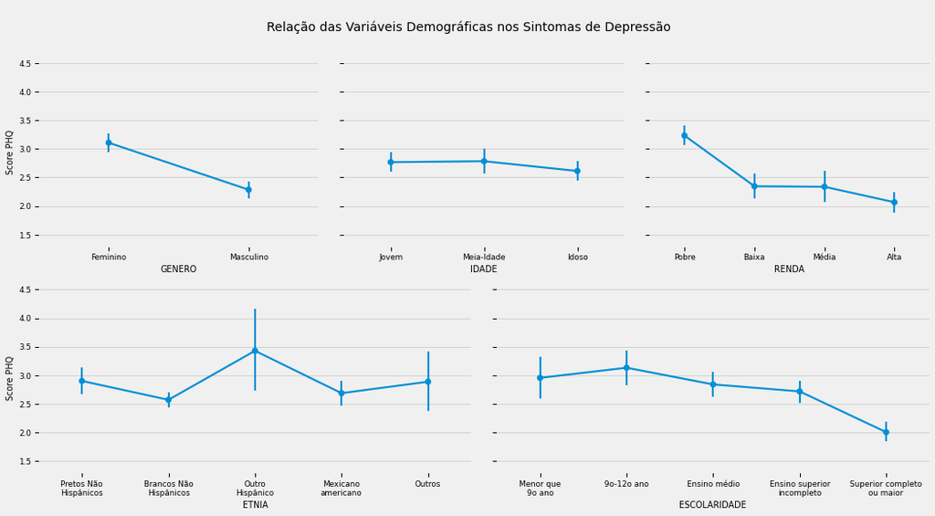

```python
demographics_graph()
```

A partir da análise, o perfil de maior incidência dos sintomas da depressão é:

Compararemos de forma semelhante a relação entre os Hábitos saudáveis (Nível de atividade física semanal e sua Saúde alimentar) com o Score PHQ:

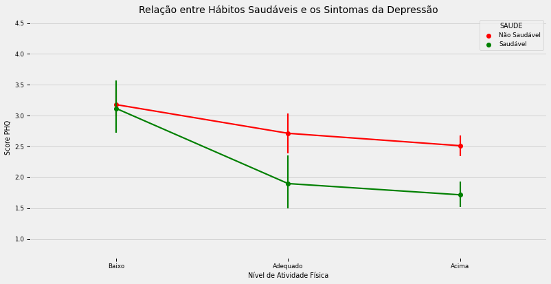

```python
health_graph()
```

Notadamente há uma diferença entre as médias dos grupos de pessoas não saudáveis e pessoas saudáveis na incidência dos sintomas de depressão, não há uma diferença significativa entre os níveis de prática de atividade física semanal Adequado e Acima, mas do nível Baixo com os superiores a diferença é clara.

# **Sumário:**

1. Sobre os Dados  
   1.1 Patient Health Questionnaire-9  
   1.2 Healthy Eating Index
2. Tratamento de Dados  
   2.1 Merge  
   2.2 Valores Nulos
3. EDA: Análise Univariada  
   3.1 Tradução das Colunas  
   3.2 Análise Univariada
4. EDA: Análise Bivariada  
   4.1 Criação de Features  
   4.2 Perfil de Indivíduos com Sintomas de Depressão  
   4.3 Hábitos Saudáveis e Atividade Física

# **1 - Sobre os Dados** ↑

## **1.1 Patient Health Questionnaire-9** ↑

O Patient Health Questionnaire-9 (PHQ-9) é um instrumento utilizado para avaliar o grau de depressão em pacientes. O questionário consiste de 9 itens em que os respondentes indicam a frequência de sintomas de depressão nas duas últimas semanas:

- 0 = “nenhuma vez”
- 1 = “menos de uma semana”
- 2 = “uma semana ou mais”
- 3 = “quase todos os dias”

**Descrição detalhada**

**DEMO_PHQ.csv**

[output not shown]

## **1.2 Healthy Eating Index** ↑

O Healthy Eating Index (HEI) é uma medida de qualidade da dieta baseado nas orientações dietéticas do governo federal americano (Dietary Guidelines for Americans). O HEI utiliza diferentes grupos alimentares para o cálculo do escore, variando de 0 a 100, em que maiores valores do escore refletem dietas mais próximas das orientações alimentares em vigor.

O índice é composto por 13 componentes baseados nos grupos alimentares descritos nas recomendações dietéticas.

**Descrição detalhada**  
**PAG_HEI.csv**

| Nome | Descrição | Valores |
| --- | --- | --- |
| SEQN | Identificador único do respondente |  |
| PAG_MINW | Tempo total semanal de atividade aeróbica moderada- vigorosa em minutos segundo o Physical Activity Guideline (PAG) |  |
| ADHERENCE | Grupo de aderência ao Physical Activity Guideline (PAG) | 1 = Baixo (< 150 min/semana) 2 = Adequado (150-300 min/semana) 3 = Acima (> 300 min/semana) |
| HEI2015C1_TOTALVEG | Healthy Eating Index - Componente 1 - Total de Vegetais | 0-5 |
| HEI2015C2_GREEN_AND_BEAN | Healthy Eating Index - Componente 2 - Verduras verde- escuras e leguminosas | 0-5 |
| HEI2015C3_TOTALFRUIT | Healthy Eating Index - Componente 3 - Frutas totais | 0-5 |
| HEI2015C4_WHOLEFRUIT | Healthy Eating Index - Componente 4 - Frutas in natura | 0-5 |
| HEI2015C5_WHOLEGRAIN | Healthy Eating Index - Componente 5 - Grãos integrais | 0-10 |
| HEI2015C6_TOTALDAIRY | Healthy Eating Index - Componente 6 - Laticínios | 0-10 |
| HEI2015C7_TOTPROT | Healthy Eating Index - Componente 7 - Proteínas | 0-5 |
| HEI2015C8_SEAPLANT_PROT | Healthy Eating Index - Componente 8 - Plantas marinhas e proteínas vegetais | 0-5 |
| HEI2015C9_FATTYACID | Healthy Eating Index - Componente 9 - Ácido-graxo | 0-10 |
| HEI2015C10_SODIUM | Healthy Eating Index - Componente 10 - Sódio | 0-10 |
| HEI2015C11_REFINEDGRAIN | Healthy Eating Index - Componente 11 - Grãos refinados | 0-10 |
| HEI2015C12_SFAT | Healthy Eating Index - Componente 12 - Gordura saturada | 0-10 |
| HEI2015C13_ADDSUG | Healthy Eating Index - Componente 13 - Açúcares adicionados | 0-10 |
| HEI2015_TOTAL_SCORE | Healthy Eating Index - Escore total | 0-100 |

```python
import pandas as pd
import numpy as np
import seaborn as sns
import matplotlib.pyplot as plt

import statsmodels.api as sm
from statsmodels.formula.api import ols
from statsmodels.stats.multicomp import pairwise_tukeyhsd

import warnings
from IPython.display import Markdown

plt.style.use('fivethirtyeight')
pd.set_option('display.max_columns', None)
pd.set_option('display.max_rows', 50)

sns.set_context('paper')

warnings.filterwarnings("ignore")
```

```python
phq = pd.read_csv('Dados/DEMO_PHQ.csv')
hei = pd.read_csv('Dados/PAG_HEI.csv')
```

# **2 - Tratamento de Dados** ↑

```python
print(f'O Dataframe PHQ possui {phq.shape[0]} linhas e {phq.shape[1]} colunas')
print(f'O Dataframe HEI possui {hei.shape[0]} linhas e {hei.shape[1]} colunas')
```

```
O Dataframe PHQ possui 5334 linhas e 15 colunas
O Dataframe HEI possui 9424 linhas e 17 colunas
```

## **2.1 Merge** ↑

Para iniciarmos a análise iremos primeiramente unir os dois Dataframes através de um outer join para não perder nenhum informação e facilitando o tratamento por termos que lidar apenas com um dataframe.

```python
df = hei.merge(right=phq, how='outer', on='SEQN', indicator=True)
```

```python
df.info()
```

```
<class 'pandas.core.frame.DataFrame'>
Int64Index: 9424 entries, 0 to 9423
Data columns (total 32 columns):
 #   Column                    Non-Null Count  Dtype
---  ------                    --------------  -----
 0   SEQN                      9424 non-null   int64
 1   PAG_MINW                  7150 non-null   float64
 2   ADHERENCE                 7150 non-null   float64
 3   HEI2015C1_TOTALVEG        8549 non-null   float64
 4   HEI2015C2_GREEN_AND_BEAN  8549 non-null   float64
 5   HEI2015C3_TOTALFRUIT      8549 non-null   float64
 6   HEI2015C4_WHOLEFRUIT      8549 non-null   float64
 7   HEI2015C5_WHOLEGRAIN      8549 non-null   float64
 8   HEI2015C6_TOTALDAIRY      8549 non-null   float64
 9   HEI2015C7_TOTPROT         8549 non-null   float64
```

[output cut: 24 more lines]

```python
df._merge.value_counts()
```

```
both          5334
left_only     4090
right_only       0
Name: _merge, dtype: int64
```

Note que todos os campos chaves presentes em PHQ estão em HEI, mas nem todos os presentes em HEI estão em PHQ.  
Dado que as informações principais para nossa análise (sintomas de depressão) estão em PHQ, podemos remover todos os casos em que o cruzamento não foi bem sucedido sem perda de informações para nossa análise.

```python
df2 = df.query('_merge == "both"').drop('_merge', axis=1)
```

## **2.2 Valores nulos** ↑

Aqui temos dois tipos diferentes de valores nulos:

1. Dados faltantes - por motivos desconhecidos o Dataframe possui informações missing;
2. Não respostas - o respondente da pesquisa optou por não respoder ou não sabia responder (Respostas 7 ou 9).

Como não sabemos a causa dos dados faltantes iremos removê-los.

```python
pd.DataFrame(df2.isna().sum(), columns=['Dados Faltantes'])
```

|  | Dados Faltantes |
| --- | --- |
| SEQN | 0 |
| PAG_MINW | 0 |
| ADHERENCE | 0 |
| HEI2015C1_TOTALVEG | 274 |
| HEI2015C2_GREEN_AND_BEAN | 274 |
| HEI2015C3_TOTALFRUIT | 274 |
| HEI2015C4_WHOLEFRUIT | 274 |
| HEI2015C5_WHOLEGRAIN | 274 |
| HEI2015C6_TOTALDAIRY | 274 |
| HEI2015C7_TOTPROT | 274 |
| HEI2015C8_SEAPLANT_PROT | 274 |
| HEI2015C9_FATTYACID | 274 |
| HEI2015C10_SODIUM | 274 |
| HEI2015C11_REFINEDGRAIN | 274 |
| HEI2015C12_SFAT | 274 |
| HEI2015C13_ADDSUG | 274 |
| HEI2015_TOTAL_SCORE | 274 |
| DPQ010 | 498 |
| DPQ020 | 498 |
| DPQ030 | 498 |
| DPQ040 | 498 |
| DPQ050 | 498 |
| DPQ060 | 498 |
| DPQ070 | 498 |
| DPQ080 | 498 |
| DPQ090 | 498 |
| RIAGENDR | 0 |
| RIDAGEYR | 0 |
| RIDRETH1 | 0 |
| DMDEDUC | 0 |
| INDFMINC | 47 |

```python
def calc_reducao_dataframe(df_inicial, df_final):

    print(
f'''Tamanho inicial do Dataframe: {len(df_inicial)}
Após a remoção: {len(df_final)}
Redução de {((len(df_inicial)-len(df_final))/len(df_inicial)) * 100:.2f}%''')
```

```python
df3 = df2.dropna()

calc_reducao_dataframe(df2, df3)
```

```
Tamanho inicial do Dataframe: 5334
Após a remoção: 4702
Redução de 11.85%
```

As colunas que possibilitam não respostas são:

- DPQ*
- DMDEUC
- INDFMINC (As não respostas para este caso são 77 e 99)

```python
non_response = list(df3.columns[df3.columns.str.startswith('DPQ')])
non_response.append('DMDEDUC')

pd.DataFrame((((df3[non_response] == 7 ) | (df3[non_response] == 9))).sum(), columns=['Nao Resposta'])
```

|  | Nao Resposta |
| --- | --- |
| DPQ010 | 8 |
| DPQ020 | 5 |
| DPQ030 | 6 |
| DPQ040 | 5 |
| DPQ050 | 3 |
| DPQ060 | 4 |
| DPQ070 | 2 |
| DPQ080 | 9 |
| DPQ090 | 2 |
| DMDEDUC | 1 |

```python
((df3['INDFMINC'] == 77 ) | (df3['INDFMINC'] == 9)).sum()
```

```
295
```

```python
df4 = df3[~((df3[non_response] == 7 ) | (df3[non_response] == 9)).any(axis=1)]

calc_reducao_dataframe(df3, df4)
```

```
Tamanho inicial do Dataframe: 4702
Após a remoção: 4668
Redução de 0.72%
```

```python
df5 = df4[~((df4['INDFMINC'] == 77 ) | (df4['INDFMINC'] == 99))]

calc_reducao_dataframe(df4, df5)
```

```
Tamanho inicial do Dataframe: 4668
Após a remoção: 4592
Redução de 1.63%
```

O volume de não respostas é praticamente insignificativo, também removeremos esses casos.

# **3 - EDA: Analise Univariada** ↑

## **3.1 Tradução das Colunas** ↑

```python
df5['GENERO'] = df5['RIAGENDR'].map({
    1:'Masculino',
    2:'Feminino'
})

df5['IDADE'] = pd.cut(
    df5['RIDAGEYR'],
    bins=[0,33,50,100],
    right=False,
    labels=['Jovem', 'Meia-Idade', 'Idoso']
)

df5['ETNIA'] = df5['RIDRETH1'].map({
    1:'Mexicano\namericano',
    2:'Outro\nHispânico',
    3:'Brancos Não\nHispânicos',
    4:'Pretos Não\nHispânicos',
    5:'Outros'
})

df5['ESCOLARIDADE'] = pd.cut(
    df5['DMDEDUC'],
    bins=5,
    labels=[
        'Menor que\n9o ano',
        '9o-12o ano',
        'Ensino médio',
        'Ensino superior\nincompleto',
        'Superior completo\nou maior'
    ]
)

df5['NIVEL_ATIVIDADE_FISICA'] = pd.cut(
    df5['ADHERENCE'],
    bins=3,
    labels=[
        'Baixo',
        'Adequado',
        'Acima',
    ]
)
```

Note que para coluna INDFMINC temos uma codificação peculiar, os grupos 12 e 13 não seguem a logica ordinal dos grupos 1 a 11, recodificaremos da seguinte forma:

- 12 (Maior que 20000) -> 5 (20000-25000)
- 13 (Menor que 20000) -> 2 (5000-9999)

```python
df5.loc[df5['INDFMINC']==12, 'INDFMINC'] = 5
df5.loc[df5['INDFMINC']==13, 'INDFMINC'] = 2
```

Para análise de renda, é interessante reagruparmos as rendas de acordo com o estrato:

```python
# Referência
# https://money.usnews.com/money/personal-finance/family-finance/articles/where-do-i-fall-in-the-american-economic-class-system

df5['RENDA'] = pd.cut(
    df5['INDFMINC'],
    bins=[0, 6, 8, 10, 12],
    labels=[
        'Pobre',
        'Baixa',
        'Média',
        'Alta'
    ]
)
```

## **3.2 Análise Univariada** ↑

### **Sintomas de Depressão**

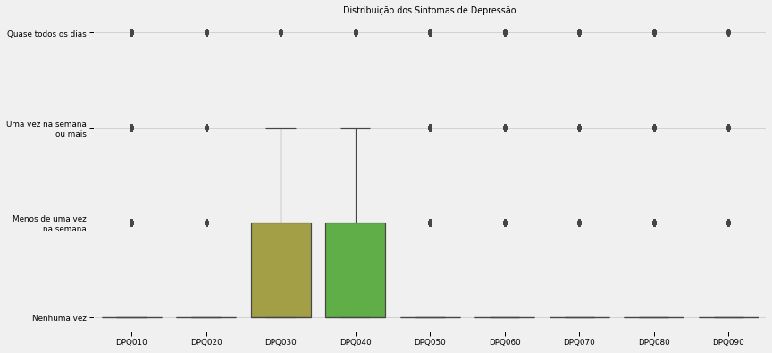

```python
dpq_vars = df5.columns[df5.columns.str.startswith('DPQ')]

fig, ax = plt.subplots(figsize=(12,6))
sns.boxplot(data=df5[dpq_vars])

plt.title('Distribuição dos Sintomas de Depressão')
plt.yticks([0, 1, 2, 3], labels=['Nenhuma vez',
                                 'Menos de uma vez\nna semana',
                                 'Uma vez na semana\nou mais',
                                 'Quase todos os dias'])
plt.show()
```

Os sintomas mais comuns são:

- DPQ030: Dificuldade para pegar no sono ou permanecer dormindo;
- DPQ040: Se sentiu cansado ou com pouca energia.

### **Índices de Saúde**

Quanto maior melhor

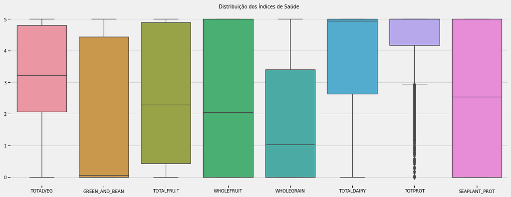

```python
hei_vars = df5.columns[df5.columns.str.startswith('HEI2015C')]

fig, ax = plt.subplots(figsize=(16,6))
sns.boxplot(data=df5[hei_vars[:8]], ax=ax)

plt.title('Distribuição dos Índices de Saúde')
ax.set_xticklabels(labels=pd.Series(hei_vars[:8]).str.split('_', n=1, expand=True)[1].to_list())

plt.show()
```

Percebe-se uma menor nota para *Green And Bean* (Verduras e Leguminosas) e *Whole Grain* (Grãos integrais)

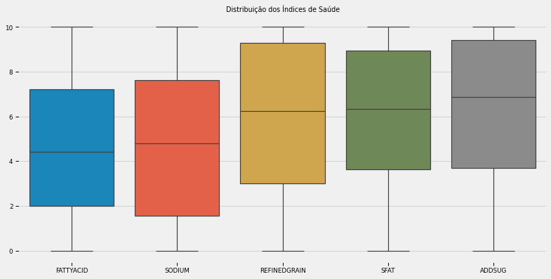

```python
fig, ax = plt.subplots(figsize=(12,6))
sns.boxplot(data=df5[hei_vars[8:]], ax=ax)

plt.title('Distribuição dos Índices de Saúde')
ax.set_xticklabels(labels=pd.Series(hei_vars[8:]).str.split('_', n=1, expand=True)[1].to_list())

plt.show()
```

Os piores indíces para esses indicadores são *Fatty Acid* (Ácidos Graxos) e *Sodium* (Sódio)

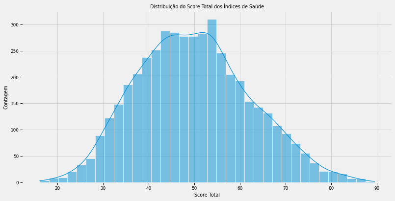

```python
fig, ax = plt.subplots(figsize=(12,6))
sns.histplot(data=df5['HEI2015_TOTAL_SCORE'], kde=True, ax=ax)

plt.title('Distribuição do Score Total dos Índices de Saúde')
plt.xlabel('Score Total')
plt.ylabel('Contagem')
plt.show()
```

### **Informações Demográficas**

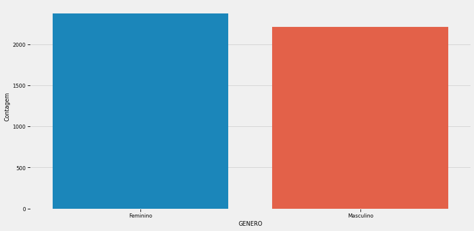

```python
fig, ax = plt.subplots(figsize=(12,6))
sns.countplot(data=df5, x='GENERO', ax=ax)

plt.ylabel('Contagem')
plt.show()
```

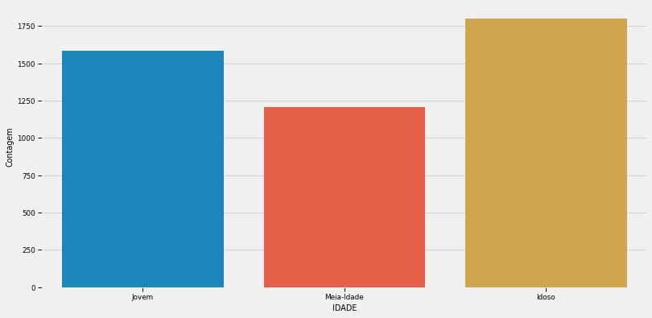

```python
fig, ax = plt.subplots(figsize=(12,6))
sns.countplot(data=df5, x='IDADE', ax=ax)

plt.ylabel('Contagem')
plt.show()
```

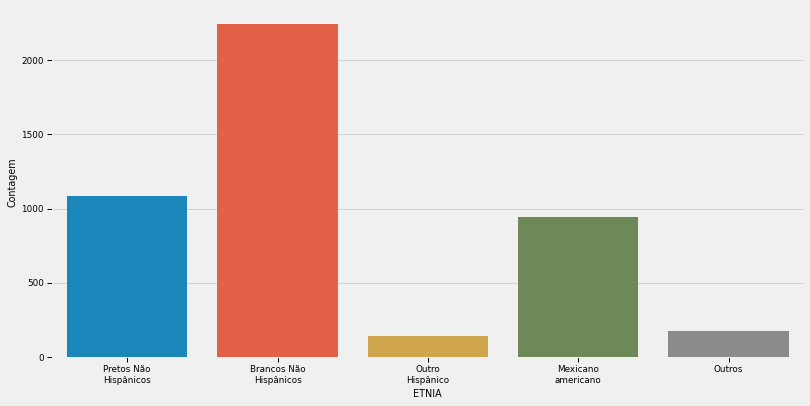

```python
fig, ax = plt.subplots(figsize=(12,6))
sns.countplot(data=df5, x='ETNIA', ax=ax)

plt.ylabel('Contagem')
plt.show()
```

```python
pd.DataFrame(df5['ETNIA'].value_counts())
```

|  | ETNIA |
| --- | --- |
| Brancos Não\nHispânicos | 2244 |
| Pretos Não\nHispânicos | 1088 |
| Mexicano\namericano | 941 |
| Outros | 179 |
| Outro\nHispânico | 140 |

Aqui temos um ponto de atenção, o número de pessoas que caem no grupo "Outro Hispânico" e "Outros" aparenta ser baixo. Uma alternativa seria agrupas os dois grupos em um único.

Deixaremos como está.

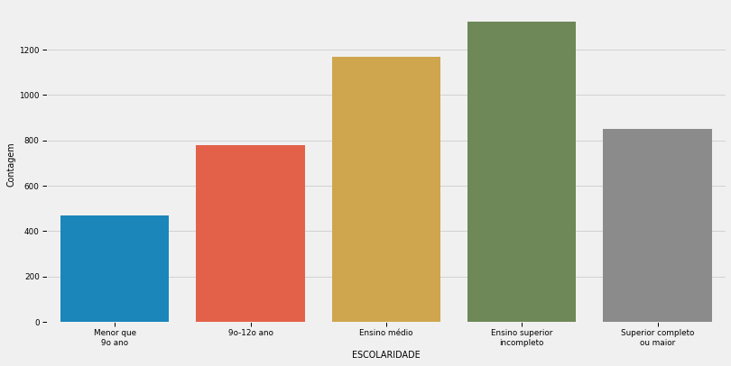

```python
fig, ax = plt.subplots(figsize=(12,6))
sns.countplot(data=df5, x='ESCOLARIDADE', ax=ax)

plt.ylabel('Contagem')
plt.show()
```

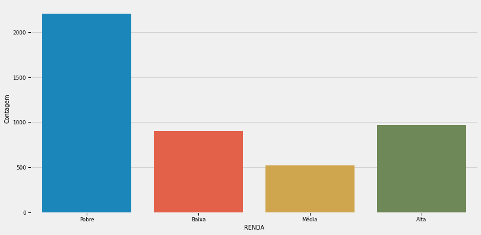

```python
fig, ax = plt.subplots(figsize=(12,6))
sns.countplot(data=df5, x='RENDA', ax=ax)

plt.ylabel('Contagem')
plt.show()
```

### **Atividade física**

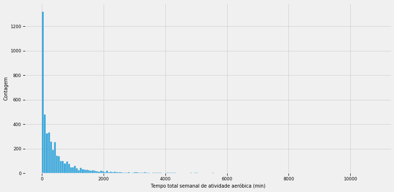

```python
fig, ax = plt.subplots(figsize=(12,6))
sns.histplot(df5['PAG_MINW'])

plt.ylabel('Contagem')
plt.xlabel('Tempo total semanal de atividade aeróbica (min)')
plt.show()
```

```python
pd.DataFrame(df5['PAG_MINW'].describe(percentiles=[.25,.5,.75,.95,.99]))
```

|  | PAG_MINW |
| --- | --- |
| count | 4592.000000 |
| mean | 489.844169 |
| std | 802.216509 |
| min | 0.000000 |
| 25% | 48.498845 |
| 50% | 221.709007 |
| 75% | 588.672055 |
| 95% | 1886.351039 |
| 99% | 3817.916397 |
| max | 10777.829099 |

Para atividade física claramente podemos perceber outliers nos dados, é impossível praticar 10777 minutos em uma semana, já que em uma semana temos apenas 10080 minutos.

É interessante utilizarmos os dados agrupados durante a análise bivariada.

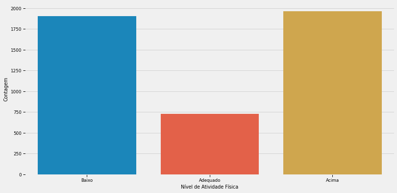

```python
fig, ax = plt.subplots(figsize=(12,6))
sns.countplot(data=df5, x='NIVEL_ATIVIDADE_FISICA', ax=ax)

plt.ylabel('Contagem')
plt.xlabel('Nível de Atividade Física')
plt.show()
```

# **4 - EDA: Analise Bivariada** ↑

## **4.1 Criação de Features** ↑

Criaremos o indicador *phq9* correspondendo a soma dos resultados das perguntas DPQ para um determinado indivíduo.

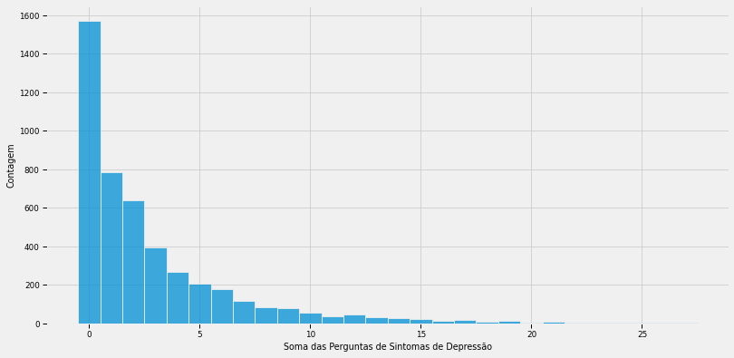

```python
df5['phq9'] = df5[dpq_vars].sum(axis=1)

fig, ax = plt.subplots(figsize=(12,6))
sns.histplot(df5, x='phq9', discrete=True, ax=ax)
plt.ylabel('Contagem')
plt.xlabel('Soma das Perguntas de Sintomas de Depressão')
plt.show()
```

Trataremos o Score total de saúde como uma variável categórica:

- Até 60 - Não Saudável;
- Acima de 60 - Saudável.

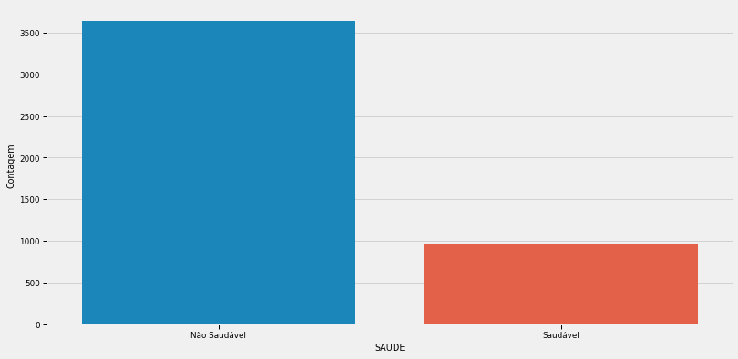

```python
df5['SAUDE'] = pd.cut(df5.HEI2015_TOTAL_SCORE, bins=[0,60,100], labels=['Não Saudável', 'Saudável'])

fig, ax = plt.subplots(figsize=(12,6))
sns.countplot(df5['SAUDE'])
plt.ylabel('Contagem')
plt.show()
```

## **4.2 Perfil de Indivíduos com Sintomas de Depressão** ↑

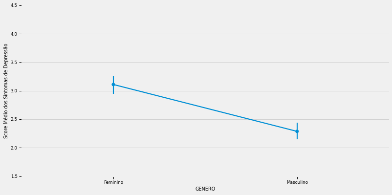

**ANOVA: GENERO**

|  | sum_sq | df | F | PR(>F) |
| --- | --- | --- | --- | --- |
| GENERO | 775.304136 | 1.0 | 56.665862 | 6.181166e-14 |
| Residual | 62800.526657 | 4590.0 | NaN | NaN |

**Teste POST-HOC ANOVA - Pairwise Tukey: GENERO**

Multiple Comparison of Means - Tukey HSD, FWER=0.05

| group1 | group2 | meandiff | p-adj | lower | upper | reject |
| --- | --- | --- | --- | --- | --- | --- |
| Feminino | Masculino | -0.8223 | 0.0 | -1.0365 | -0.6082 | True |

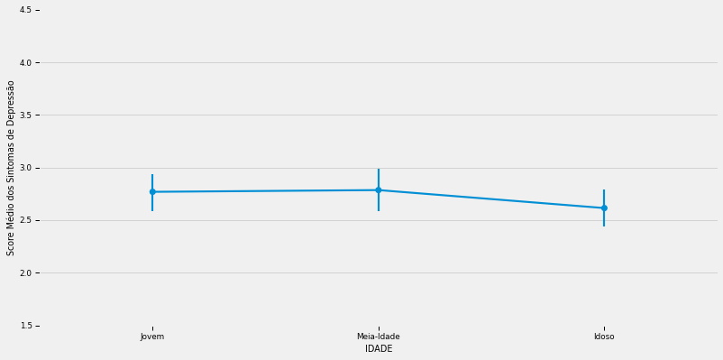

**ANOVA: IDADE**

|  | sum_sq | df | F | PR(>F) |
| --- | --- | --- | --- | --- |
| IDADE | 28.720945 | 2.0 | 1.037029 | 0.354589 |
| Residual | 63547.109848 | 4589.0 | NaN | NaN |

**Teste POST-HOC ANOVA - Pairwise Tukey: IDADE**

Multiple Comparison of Means - Tukey HSD, FWER=0.05

| group1 | group2 | meandiff | p-adj | lower | upper | reject |
| --- | --- | --- | --- | --- | --- | --- |
| Idoso | Jovem | 0.1543 | 0.4509 | -0.1462 | 0.4548 | False |
| Idoso | Meia-Idade | 0.1709 | 0.4329 | -0.1537 | 0.4955 | False |
| Jovem | Meia-Idade | 0.0166 | 0.9925 | -0.3166 | 0.3499 | False |

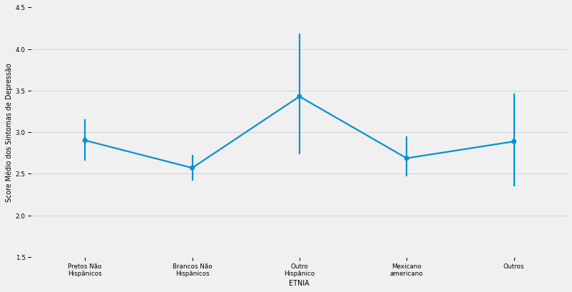

**ANOVA: ETNIA**

|  | sum_sq | df | F | PR(>F) |
| --- | --- | --- | --- | --- |
| ETNIA | 161.566366 | 4.0 | 2.921681 | 0.019944 |
| Residual | 63414.264427 | 4587.0 | NaN | NaN |

**Teste POST-HOC ANOVA - Pairwise Tukey: ETNIA**

Multiple Comparison of Means - Tukey HSD, FWER=0.05

| group1 | group2 | meandiff | p-adj | lower | upper | reject |
| --- | --- | --- | --- | --- | --- | --- |
| Brancos Não Hispânicos | Mexicano americano | 0.1163 | 0.9291 | -0.2778 | 0.5103 | False |
| Brancos Não Hispânicos | Outro Hispânico | 0.8573 | 0.0624 | -0.0266 | 1.7411 | False |
| Brancos Não Hispânicos | Outros | 0.317 | 0.8079 | -0.4711 | 1.105 | False |
| Brancos Não Hispânicos | Pretos Não Hispânicos | 0.3304 | 0.1141 | -0.0445 | 0.7052 | False |
| Mexicano americano | Outro Hispânico | 0.741 | 0.1798 | -0.1781 | 1.6601 | False |
| Mexicano americano | Outros | 0.2007 | 0.9644 | -0.6267 | 1.0281 | False |
| Mexicano americano | Pretos Não Hispânicos | 0.2141 | 0.6953 | -0.2376 | 0.6658 | False |
| Outro Hispânico | Outros | -0.5403 | 0.6987 | -1.6851 | 0.6045 | False |
| Outro Hispânico | Pretos Não Hispânicos | -0.5269 | 0.5114 | -1.4379 | 0.3841 | False |
| Outros | Pretos Não Hispânicos | 0.0134 | 1.0 | -0.805 | 0.8318 | False |

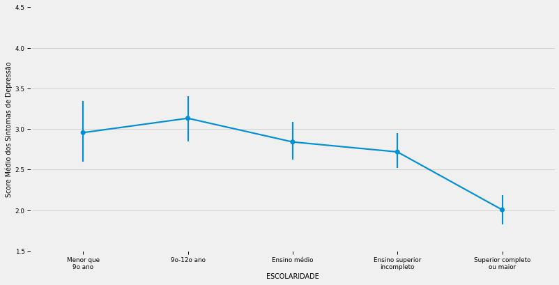

**ANOVA: ESCOLARIDADE**

|  | sum_sq | df | F | PR(>F) |
| --- | --- | --- | --- | --- |
| ESCOLARIDADE | 609.111566 | 4.0 | 11.093141 | 5.917759e-09 |
| Residual | 62966.719227 | 4587.0 | NaN | NaN |

**Teste POST-HOC ANOVA - Pairwise Tukey: ESCOLARIDADE**

Multiple Comparison of Means - Tukey HSD, FWER=0.05

| group1 | group2 | meandiff | p-adj | lower | upper | reject |
| --- | --- | --- | --- | --- | --- | --- |
| 9o-12o ano | Ensino médio | -0.2915 | 0.4337 | -0.7593 | 0.1763 | False |
| 9o-12o ano | Ensino superior incompleto | -0.4141 | 0.0967 | -0.8708 | 0.0426 | False |
| 9o-12o ano | Menor que 9o ano | -0.1771 | 0.9252 | -0.7677 | 0.4136 | False |
| 9o-12o ano | Superior completo ou maior | -1.1265 | 0.0 | -1.628 | -0.625 | True |
| Ensino médio | Ensino superior incompleto | -0.1226 | 0.9231 | -0.5284 | 0.2832 | False |
| Ensino médio | Menor que 9o ano | 0.1144 | 0.98 | -0.4378 | 0.6666 | False |
| Ensino médio | Superior completo ou maior | -0.835 | 0.0 | -1.2906 | -0.3794 | True |
| Ensino superior incompleto | Menor que 9o ano | 0.237 | 0.7563 | -0.3058 | 0.7799 | False |
| Ensino superior incompleto | Superior completo ou maior | -0.7124 | 0.0001 | -1.1566 | -0.2682 | True |
| Menor que 9o ano | Superior completo ou maior | -0.9494 | 0.0001 | -1.5305 | -0.3684 | True |

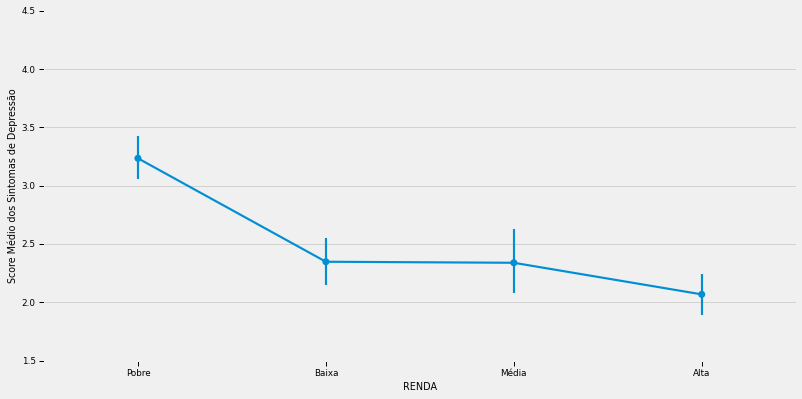

**ANOVA: RENDA**

|  | sum_sq | df | F | PR(>F) |
| --- | --- | --- | --- | --- |
| RENDA | 1195.389155 | 3.0 | 29.306437 | 9.203887e-19 |
| Residual | 62380.441638 | 4588.0 | NaN | NaN |

**Teste POST-HOC ANOVA - Pairwise Tukey: RENDA**

Multiple Comparison of Means - Tukey HSD, FWER=0.05

| group1 | group2 | meandiff | p-adj | lower | upper | reject |
| --- | --- | --- | --- | --- | --- | --- |
| Alta | Baixa | 0.2797 | 0.3565 | -0.1588 | 0.7182 | False |
| Alta | Média | 0.2709 | 0.5309 | -0.2447 | 0.7865 | False |
| Alta | Pobre | 1.1664 | -0.0 | 0.8013 | 1.5314 | True |
| Baixa | Média | -0.0088 | 1.0 | -0.5315 | 0.5138 | False |
| Baixa | Pobre | 0.8867 | 0.0 | 0.5118 | 1.2615 | True |
| Média | Pobre | 0.8955 | 0.0 | 0.4327 | 1.3582 | True |

```python
features = ['GENERO', 'IDADE', 'ETNIA', 'ESCOLARIDADE', 'RENDA']

for feature in features:
    fig, ax = plt.subplots(figsize=(12,6))
    sns.pointplot(data=df5, y='phq9', x=feature, estimator=np.mean)
    plt.ylim([1.5, 4.5])
    plt.ylabel('Score Médio dos Sintomas de Depressão')
    plt.show()

    model = ols(f'phq9 ~ {feature}', data=df5).fit()
    display(Markdown(f'**ANOVA: {feature}**'))
    display(sm.stats.anova_lm(model, typ=2))

    display(Markdown(f'**Teste POST-HOC ANOVA - Pairwise Tukey: {feature}**'))

    tukey = pairwise_tukeyhsd(
        endog=df5['phq9'],
        groups=df5[feature],
        alpha=0.05
    )
    display(tukey.summary())

    display(Markdown('---'))
```

## **4.3 Hábitos Saudáveis e Atividade Física** ↑

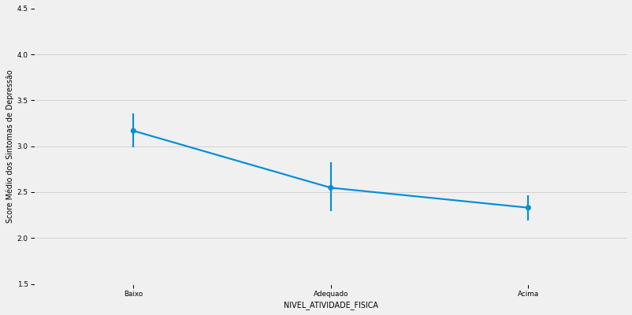

**ANOVA: NIVEL_ATIVIDADE_FISICA**

|  | sum_sq | df | F | PR(>F) |
| --- | --- | --- | --- | --- |
| NIVEL_ATIVIDADE_FISICA | 700.291390 | 2.0 | 25.555544 | 9.177409e-12 |
| Residual | 62875.539403 | 4589.0 | NaN | NaN |

**Teste POST-HOC ANOVA - Pairwise Tukey: NIVEL_ATIVIDADE_FISICA**

Multiple Comparison of Means - Tukey HSD, FWER=0.05

| group1 | group2 | meandiff | p-adj | lower | upper | reject |
| --- | --- | --- | --- | --- | --- | --- |
| Acima | Adequado | 0.217 | 0.3675 | -0.1598 | 0.5938 | False |
| Acima | Baixo | 0.8371 | 0.0 | 0.5579 | 1.1163 | True |
| Adequado | Baixo | 0.6201 | 0.0004 | 0.2417 | 0.9984 | True |

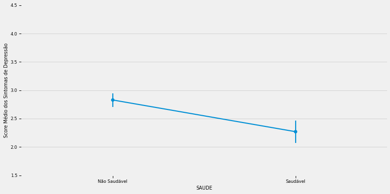

**ANOVA: SAUDE**

|  | sum_sq | df | F | PR(>F) |
| --- | --- | --- | --- | --- |
| SAUDE | 235.673601 | 1.0 | 17.078294 | 0.000037 |
| Residual | 63340.157191 | 4590.0 | NaN | NaN |

**Teste POST-HOC ANOVA - Pairwise Tukey: SAUDE**

Multiple Comparison of Means - Tukey HSD, FWER=0.05

| group1 | group2 | meandiff | p-adj | lower | upper | reject |
| --- | --- | --- | --- | --- | --- | --- |
| Não Saudável | Saudável | -0.5588 | 0.0 | -0.824 | -0.2937 | True |

```python
features = ['NIVEL_ATIVIDADE_FISICA', 'SAUDE']

for feature in features:
    fig, ax = plt.subplots(figsize=(12,6))
    sns.pointplot(data=df5, y='phq9', x=feature, estimator=np.mean)
    plt.ylim([1.5, 4.5])
    plt.ylabel('Score Médio dos Sintomas de Depressão')
    plt.show()

    model = ols(f'phq9 ~ {feature}', data=df5).fit()
    display(Markdown(f'**ANOVA: {feature}**'))
    display(sm.stats.anova_lm(model, typ=2))

    display(Markdown(f'**Teste POST-HOC ANOVA - Pairwise Tukey: {feature}**'))
    tukey = pairwise_tukeyhsd(
        endog=df5['phq9'],
        groups=df5[feature],
        alpha=0.05
    )
    display(tukey.summary())
    display(Markdown('---'))
```

**Funções utilizadas no Resumo**

```python
def demographics_graph():
    # Construção da Figura
    fig, axs = plt.subplots(ncols=6, nrows=2, figsize=(16,8), subplot_kw= {'ylim':[1.3, 4.6]})
    gs = axs[0, 1].get_gridspec()

    # Como todos os spots serão alterados, removeremos
    # todos os axis
    for row in axs:
        for ax in row:
            ax.remove()

    # Construção dos novos subplots
    ax0 = fig.add_subplot(gs[0, 0:2])
    ax1 = fig.add_subplot(gs[0, 2:4])
    ax2 = fig.add_subplot(gs[0, 4:6])
    ax3 = fig.add_subplot(gs[1, 0:3])
    ax4 = fig.add_subplot(gs[1, 3:6])


    all_axis = [ax0, ax1, ax2, ax3, ax4]
    features = ['GENERO', 'IDADE', 'RENDA', 'ETNIA', 'ESCOLARIDADE']

    # Point Plots
    sns.pointplot(data=df5, y='phq9', x=features[0], estimator=np.mean, ax=ax0)
    sns.pointplot(data=df5, y='phq9', x=features[1], estimator=np.mean, ax=ax1)
    sns.pointplot(data=df5, y='phq9', x=features[2], estimator=np.mean, ax=ax2)

    sns.pointplot(data=df5, y='phq9', x=features[3], estimator=np.mean, ax=ax3)
    sns.pointplot(data=df5, y='phq9', x=features[4], estimator=np.mean, ax=ax4)

    # Mudança de Labels
    for ax in all_axis:
        ax.set_ylim(1.3, 4.6)
        ax.set_ylabel('')
        ax.set_yticklabels([''])

    ax0.set_yticklabels([1, 1.5, 2.0, 2.5, 3.0, 3.5, 4.0, 4.5])
    ax0.set_ylabel('Score PHQ')
    ax3.set_yticklabels([1, 1.5, 2.0, 2.5, 3.0, 3.5, 4.0, 4.5])
    ax3.set_ylabel('Score PHQ')

    fig.suptitle('\nRelação das Variáveis Demográficas nos Sintomas de Depressão', fontsize=14)
    plt.show()
```

```python
from IPython.core.display import HTML
HTML("""
<style>
.output_png {
    display: table-cell;
    text-align: center;
    vertical-align: middle;
}
</style>
""")
```

```python
def health_graph():

    fig, ax = plt.subplots(figsize=(12,6))

    sns.pointplot(data=df5, y='phq9', x='NIVEL_ATIVIDADE_FISICA', hue='SAUDE', estimator=np.mean, palette=['r', 'g'])

    plt.ylim([.7, 4.6])
    plt.ylabel('Score PHQ')
    plt.xlabel('Nível de Atividade Física')
    plt.title('Relação entre Hábitos Saudáveis e os Sintomas da Depressão', fontdict={'fontsize':14})

    plt.show()
```